# Biostat 203B Homework 4 Solution

Due Mar 20 @ 11:59PM

Supasara Prasertphong (UID:905226886)

# Task

In this assignment, you are to write a report analyzing the electronic health record (EHR) data MIMIC-III. You report will demostrate your knowledge of working with PostgreSQL database, data visualization, and commonly used analytical methods such as logistic regression and neural network. Your report should include at least following parts:

# Learning resources about analyzing EHR data

- *Secondary Analysis of Electronic Health Records*: https://link.springer.com/book/10.1007/978-3-319-43742-2
- *The Book of OHDSI*: https://ohdsi.github.io/TheBookOfOhdsi/.
- The GitHub repository https://github.com/MIT-LCP/mimic-code contains some code examples for working with the MIMIC-III data. Following sample code derives from https://github.com/MIT-LCP/mimic-code/blob/master/tutorials/dplyr-frontend/intro.md.

# Examplary code

## Connect to PostgresSQL database

Load database libraries and the tidyverse frontend:

```r
library(DBI)
library(RPostgreSQL)
library(tidyverse)
library(lubridate)
```

```r
library(dplyr)
library(ggplot2)
```

Credentials for using PostgreSQL database. We are going to use username `postgres` with password `postgres` to access the `mimic` database in the schemee `mimiciii`.

```r
# Load configuration settings
dbdriver <- 'PostgreSQL'
#host  <- '127.0.0.1'
#port  <- '5432'
user  <- 'postgres'
password <- 'postgres'
dbname <- 'mimic'
schema <- 'mimiciii'
# Connect to the database using the configuration settings
con <- dbConnect(RPostgreSQL::PostgreSQL(),
                 dbname = dbname,
                 #host = host,
                 #port = port,
                 user = user,
                 password = password)
# Set the default schema
dbExecute(con, paste("SET search_path TO ", schema, sep=" "))
```

```
## [1] 0
```

```r
con
```

```
## <PostgreSQLConnection>
```

List tables in the `mimic` database:

```r
dbListTables(con)
```

```
##   [1] "admissions"         "callout"            "caregivers"
##   [4] "chartevents_1"      "chartevents"        "chartevents_2"
##   [7] "chartevents_3"      "chartevents_4"      "chartevents_5"
##  [10] "chartevents_6"      "chartevents_7"      "chartevents_8"
##  [13] "chartevents_9"      "chartevents_10"     "inputevents_mv"
##  [16] "labevents"          "chartevents_11"     "chartevents_12"
##  [19] "chartevents_13"     "chartevents_14"     "microbiologyevents"
##  [22] "chartevents_15"     "chartevents_16"     "chartevents_17"
##  [25] "chartevents_18"     "chartevents_19"     "chartevents_20"
##  [28] "chartevents_21"     "chartevents_22"     "chartevents_23"
##  [31] "noteevents"         "outputevents"       "chartevents_24"
##  [34] "chartevents_25"     "chartevents_26"     "chartevents_27"
##  [37] "chartevents_28"     "patients"           "chartevents_29"
##  [40] "chartevents_30"     "chartevents_31"     "chartevents_32"
##  [43] "chartevents_33"     "chartevents_34"     "chartevents_35"
```

[output cut: 66 more lines]

An example SQL query:

```r
sql_query <- "SELECT i.subject_id, i.hadm_id, i.los
              FROM icustays i;"
(data <- dbGetQuery(con, sql_query)) %>% as_tibble()
```

```
## # A tibble: 61,532 x 3
##    subject_id hadm_id   los
##         <int>   <int> <dbl>
##  1        268  110404 3.25
##  2        269  106296 3.28
##  3        270  188028 2.89
##  4        271  173727 2.06
##  5        272  164716 1.62
##  6        273  158689 1.49
##  7        274  130546 8.81
##  8        275  129886 7.13
##  9        276  135156 1.34
## 10        277  171601 0.731
## # … with 61,522 more rows
```

```r
#This document shows how RMarkdown can be used to create a reproducible analysis using MIMIC-III (version 1.4). Let's calculate the median length of stay in the ICU and then include this value in our document.
(avg_los <- median(data$los, na.rm=TRUE))
```

```
## [1] 2.09225
```

```r
(rounded_avg_los <- round(avg_los, digits = 2))
```

```
## [1] 2.09
```

## Connect to a table in database

To connect to the `patients` table in the database:

```r
patients <- tbl(con, "patients")
patients %>% print(width = Inf)
```

```
## # Source:   table<patients> [?? x 8]
## # Database: postgres 11.0.7 [postgres@/var/run/postgresql:5432/mimic]
##    row_id subject_id gender dob                 dod
##     <int>      <int> <chr>  <dttm>              <dttm>
##  1    234        249 F      2075-03-13 00:00:00 NA
##  2    235        250 F      2164-12-27 00:00:00 2188-11-22 00:00:00
##  3    236        251 M      2090-03-15 00:00:00 NA
##  4    237        252 M      2078-03-06 00:00:00 NA
##  5    238        253 F      2089-11-26 00:00:00 NA
##  6    239        255 M      2109-08-05 00:00:00 NA
##  7    240        256 M      2086-07-31 00:00:00 NA
##  8    241        257 F      2031-04-03 00:00:00 2121-07-08 00:00:00
##  9    242        258 F      2124-09-19 00:00:00 NA
## 10    243        260 F      2105-03-23 00:00:00 NA
##    dod_hosp            dod_ssn             expire_flag
##    <dttm>              <dttm>                    <int>
##  1 NA                  NA                            0
##  2 2188-11-22 00:00:00 NA                            1
##  3 NA                  NA                            0
##  4 NA                  NA                            0
##  5 NA                  NA                            0
##  6 NA                  NA                            0
##  7 NA                  NA                            0
##  8 2121-07-08 00:00:00 2121-07-08 00:00:00           1
##  9 NA                  NA                            0
## 10 NA                  NA                            0
## # … with more rows
```

We can see this connection is lazy (does not load the whole table into computer memory)

```r
str(patients)
```

```
## List of 2
##  $ src:List of 2
##   ..$ con  :Formal class 'PostgreSQLConnection' [package "RPostgreSQL"] with 1 slot
##   .. .. ..@ Id: int [1:2] 13142 0
##   ..$ disco: NULL
##   ..- attr(*, "class")= chr [1:4] "src_PostgreSQLConnection" "src_dbi" "src_sql" "src"
##  $ ops:List of 2
##   ..$ x   : 'ident' chr "patients"
##   ..$ vars: chr [1:8] "row_id" "subject_id" "gender" "dob" ...
##   ..- attr(*, "class")= chr [1:3] "op_base_remote" "op_base" "op"
##  - attr(*, "class")= chr [1:5] "tbl_PostgreSQLConnection" "tbl_dbi" "tbl_sql" "tbl_lazy" ...
```

To load the entire table into memory we may use

```r
collect(patients)
```

```
## # A tibble: 46,520 x 8
##    row_id subject_id gender dob                 dod
##  *  <int>      <int> <chr>  <dttm>              <dttm>
##  1    234        249 F      2075-03-13 00:00:00 NA
##  2    235        250 F      2164-12-27 00:00:00 2188-11-22 00:00:00
##  3    236        251 M      2090-03-15 00:00:00 NA
##  4    237        252 M      2078-03-06 00:00:00 NA
##  5    238        253 F      2089-11-26 00:00:00 NA
##  6    239        255 M      2109-08-05 00:00:00 NA
##  7    240        256 M      2086-07-31 00:00:00 NA
##  8    241        257 F      2031-04-03 00:00:00 2121-07-08 00:00:00
##  9    242        258 F      2124-09-19 00:00:00 NA
## 10    243        260 F      2105-03-23 00:00:00 NA
## # … with 46,510 more rows, and 3 more variables: dod_hosp <dttm>,
## #   dod_ssn <dttm>, expire_flag <int>
```

But keep in mind that the point of using a database software is that the data tables are potentially large and we prefer to use database to do on disk computations as much as possible. So in this assignment we will avoid loading whole tables into memory as much as we can.

## Query and subsetting

First we create a (query) table of patients who were directly admitted into MICU (Medical Intensive Care Unit).

```r
tbl(con, "transfers") %>%
  select(subject_id, hadm_id, prev_careunit, curr_careunit) %>%
  filter(is.na(prev_careunit) & curr_careunit == "MICU") %>%
  select(subject_id, hadm_id) %>%
  distinct() %>%
  print() -> micu_admissions
```

```
## # Source:   lazy query [?? x 2]
## # Database: postgres 11.0.7 [postgres@/var/run/postgresql:5432/mimic]
##    subject_id hadm_id
##         <int>   <int>
##  1        711  120522
##  2      20863  195453
##  3      97716  178708
##  4      60131  190090
##  5      19705  155006
##  6      11342  165519
##  7      74147  149842
##  8      18958  122966
##  9       7681  175048
## 10      65665  170768
## # … with more rows
```

```r
tbl(con, "transfers") %>%
  group_by(subject_id, hadm_id) %>%
print() -> all_admissions
```

```
## # Source:   table<transfers> [?? x 13]
## # Database: postgres 11.0.7 [postgres@/var/run/postgresql:5432/mimic]
## # Groups:   subject_id, hadm_id
##    row_id subject_id hadm_id icustay_id dbsource eventtype prev_careunit
##     <int>      <int>   <int>      <int> <chr>    <chr>     <chr>
##  1    657        111  192123     254245 carevue  transfer  CCU
##  2    658        111  192123         NA carevue  transfer  MICU
##  3    659        111  192123         NA carevue  discharge <NA>
##  4    660        111  155897     249202 metavis… admit     <NA>
##  5    661        111  155897         NA metavis… transfer  MICU
##  6    662        111  155897     249202 metavis… transfer  <NA>
##  7    663        111  155897         NA metavis… transfer  MICU
##  8    664        111  155897     249202 metavis… transfer  <NA>
##  9    665        111  155897         NA metavis… discharge MICU
## 10    666        112  174105     289222 carevue  admit     <NA>
## # … with more rows, and 6 more variables: curr_careunit <chr>,
## #   prev_wardid <int>, curr_wardid <int>, intime <dttm>, outtime <dttm>,
## #   los <dbl>
```

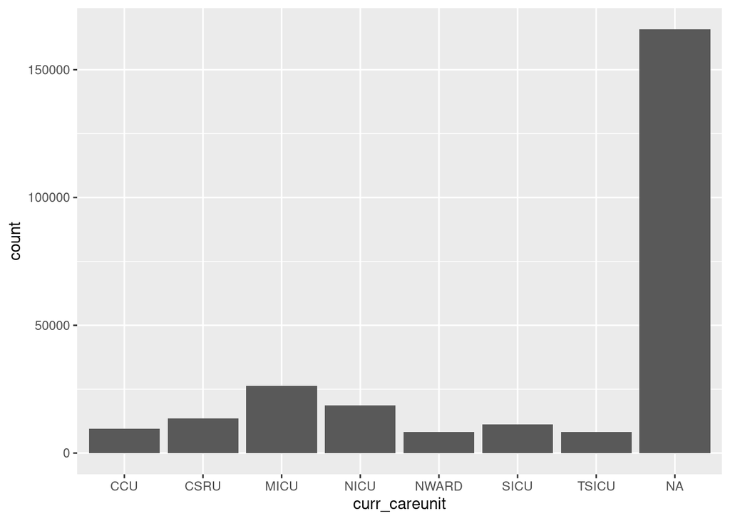

```r
all_admissions %>%
  group_by(curr_careunit) %>%
  summarize(count = n()) %>%
  ggplot(aes(x = curr_careunit, y = count)) +
  geom_col()
```

```r
tbl(con, "d_icd_diagnoses") %>%
  filter(str_detect(tolower(long_title), "respiratory")) %>%
  print() -> resp_codes
```

```
## # Source:   lazy query [?? x 4]
## # Database: postgres 11.0.7 [postgres@/var/run/postgresql:5432/mimic]
##    row_id icd9_code short_title       long_title
##     <int> <chr>     <chr>             <chr>
##  1    224 01280     Resp TB NEC-unsp… Other specified respiratory tuberculosis,…
##  2    225 01281     Resp TB NEC-no e… Other specified respiratory tuberculosis,…
##  3    226 01282     Resp TB NEC-exam… Other specified respiratory tuberculosis,…
##  4    227 01283     Resp TB NEC-micr… Other specified respiratory tuberculosis,…
##  5    228 01284     Resp TB NEC-cult… Other specified respiratory tuberculosis,…
##  6    229 01285     Resp TB NEC-hist… Other specified respiratory tuberculosis,…
##  7    230 01286     Resp TB NEC-oth … Other specified respiratory tuberculosis,…
##  8   1337 1650      Mal neo upper re… Malignant neoplasm of upper respiratory t…
##  9   1338 1658      Mal neo thorax/r… Malignant neoplasm of other sites within …
## 10   1339 1659      Mal neo resp sys… Malignant neoplasm of ill-defined sites w…
## # … with more rows
```

```r
tbl(con, "diagnoses_icd") %>%
  semi_join(resp_codes, by = "icd9_code") %>%
  print() -> resp_admissions
```

```
## # Source:   lazy query [?? x 5]
## # Database: postgres 11.0.7 [postgres@/var/run/postgresql:5432/mimic]
##    row_id subject_id hadm_id seq_num icd9_code
##     <int>      <int>   <int>   <int> <chr>
##  1  30613       2723  165399       3 1370
##  2 135508      12011  130378       6 1370
##  3 227983      20425  174834       7 1370
##  4 311388      27597  180160      15 1370
##  5  34670       3100  169134      10 0796
##  6 183070      16468  143069       6 0796
##  7 226054      20249  175360      16 0796
##  8 245238      21985  122909       4 0796
##  9 273843      24553  152313       6 0796
## 10 299832      26781  121781       5 0796
## # … with more rows
```

```r
resp_admissions %>%
  filter(seq_num <= 5) %>%
  group_by(subject_id, hadm_id) %>%
  #top_n(1, wt = seq_num) %>% #  not working. bug? use following as workaround
  filter(min_rank(seq_num) <= 1) %>%
  ungroup() %>%
  select(subject_id, hadm_id, icd9_code, seq_num) %>%
  print() -> resp_admissions
```

```
## # Source:   lazy query [?? x 4]
## # Database: postgres 11.0.7 [postgres@/var/run/postgresql:5432/mimic]
##    subject_id hadm_id icd9_code seq_num
##         <int>   <int> <chr>       <int>
##  1         36  165660 99739           5
##  2         39  106266 769             2
##  3         66  104518 77089           4
##  4         72  156857 769             2
##  5         87  190659 769             4
##  6         91  121205 51881           5
##  7         92  142807 769             4
##  8         93  160481 769             3
##  9         94  140037 51884           2
## 10        101  175533 51881           1
## # … with more rows
```

```r
micu_admissions %>%
  inner_join(resp_admissions, by = c("subject_id", "hadm_id")) %>%
  print() -> study_admissions
```

```
## # Source:   lazy query [?? x 4]
## # Database: postgres 11.0.7 [postgres@/var/run/postgresql:5432/mimic]
##    subject_id hadm_id icd9_code seq_num
##         <int>   <int> <chr>       <int>
##  1         36  165660 99739           5
##  2         91  121205 51881           5
##  3         94  140037 51884           2
##  4        101  175533 51881           1
##  5        111  155897 51881           4
##  6        141  168006 51881           3
##  7        148  199488 51881           5
##  8        157  107880 51881           4
##  9        164  182743 51884           1
## 10        165  170252 51881           2
## # … with more rows
```

## Transform and augment query tables

Created a logical variable indicating if respiratory illness was the principal diagonosis or not, whether the seq_num is 1 then it is the principal diagnosis.

```r
study_admissions %>%
  mutate(principal_dx = seq_num == 1) %>%
  #select(-seq_num) %>%
  print() -> study_admissions
```

```
## # Source:   lazy query [?? x 5]
## # Database: postgres 11.0.7 [postgres@/var/run/postgresql:5432/mimic]
##    subject_id hadm_id icd9_code seq_num principal_dx
##         <int>   <int> <chr>       <int> <lgl>
##  1         36  165660 99739           5 FALSE
##  2         91  121205 51881           5 FALSE
##  3         94  140037 51884           2 FALSE
##  4        101  175533 51881           1 TRUE
##  5        111  155897 51881           4 FALSE
##  6        141  168006 51881           3 FALSE
##  7        148  199488 51881           5 FALSE
##  8        157  107880 51881           4 FALSE
##  9        164  182743 51884           1 TRUE
## 10        165  170252 51881           2 FALSE
## # … with more rows
```

Create graph based on the seq_num, dealing with the primary diagnoses of respiratory illness. There are about 1000 patients who are seq_num = 1.

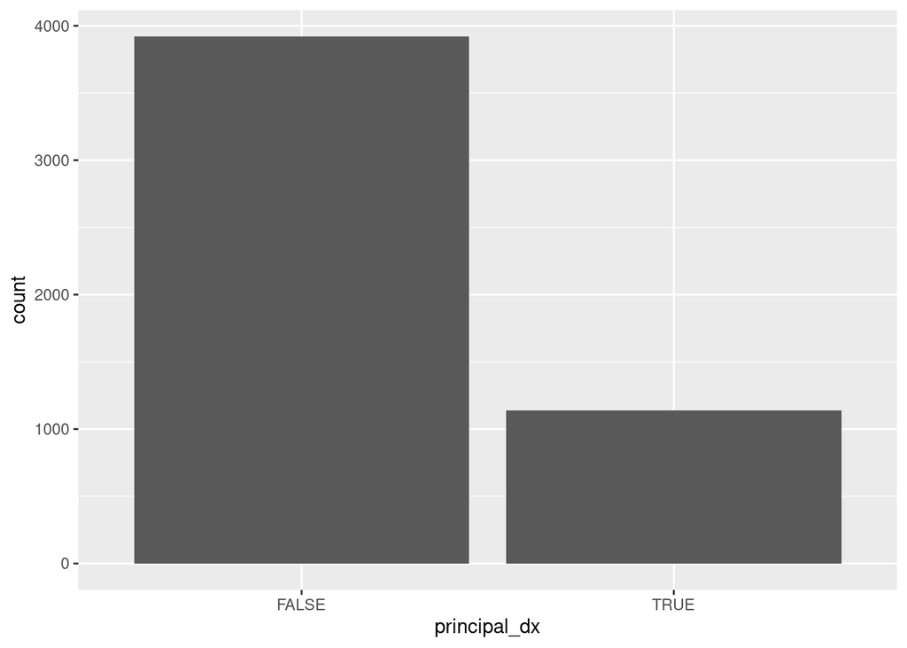

```r
study_admissions %>%
  group_by(principal_dx) %>%
  summarize(count = n()) %>%
  ggplot(aes(x = principal_dx, y = count)) +
  geom_col()
```

We want to add information about the severity of patients’ ailments. The `drgcodes` table contains, for `DRG` codes from the All Payers Registry (APR), severity and mortality indicators. We pull the drug severity information and right-join it to our query table.

```r
tbl(con, "drgcodes") %>%
  filter(str_detect(drg_type, "APR")) %>%
  select(subject_id, hadm_id, drg_severity) %>%
  right_join(study_admissions, by = c("subject_id", "hadm_id")) %>%
  mutate(drg_severity = ifelse(is.na(drg_severity), 1, drg_severity)) %>%
  print() -> study_admissions
```

```
## # Source:   lazy query [?? x 6]
## # Database: postgres 11.0.7 [postgres@/var/run/postgresql:5432/mimic]
##    subject_id hadm_id drg_severity icd9_code seq_num principal_dx
##         <int>   <int>        <dbl> <chr>       <int> <lgl>
##  1         36  165660            3 99739           5 FALSE
##  2         36  165660            3 99739           5 FALSE
##  3         91  121205            1 51881           5 FALSE
##  4         94  140037            2 51884           2 FALSE
##  5        101  175533            1 51881           1 TRUE
##  6        111  155897            4 51881           4 FALSE
##  7        111  155897            4 51881           4 FALSE
##  8        141  168006            1 51881           3 FALSE
##  9        148  199488            1 51881           5 FALSE
## 10        157  107880            4 51881           4 FALSE
## # … with more rows
```

Pull the admission time `admittime`, discharge time `dischtime`, date of birth `dob`, and date of death `dod`. We are interested in the mortality rate 30 days after discharge. So we only keep patients who didn’t die in hospital.

```r
study_admissions %>%
  left_join(
    select(tbl(con, "admissions"),
           subject_id, hadm_id, admittime, dischtime, hospital_expire_flag
    ), by = c("subject_id", "hadm_id")
  ) %>%
  filter(hospital_expire_flag == 0) %>% # patients who did not die in hospital
  select(-hospital_expire_flag) %>%
  left_join(
    select(tbl(con, "patients"), subject_id, dob, dod),
    by = "subject_id"
  ) %>%
  print(width = Inf) -> study_admissions
```

```
## # Source:   lazy query [?? x 10]
## # Database: postgres 11.0.7 [postgres@/var/run/postgresql:5432/mimic]
##    subject_id hadm_id drg_severity icd9_code seq_num principal_dx
##         <int>   <int>        <dbl> <chr>       <int> <lgl>
##  1         36  165660            3 99739           5 FALSE
##  2         36  165660            3 99739           5 FALSE
##  3         94  140037            2 51884           2 FALSE
##  4        148  199488            1 51881           5 FALSE
##  5        157  107880            4 51881           4 FALSE
##  6        165  170252            4 51881           2 FALSE
##  7        165  170252            4 51881           2 FALSE
##  8        170  175350            1 51881           3 FALSE
##  9        177  143120            1 51881           2 FALSE
## 10        186  164405            4 51881           4 FALSE
##    admittime           dischtime           dob
```

[output cut: 24 more lines]

Created a new column for the age of death and the mortality column is to see if the death is within 30 days of discharge. Subjects with respiratory illness, age, drug severity, etc…are included.

```r
study_admissions %>%
  mutate(tt_death = date_part("day", dod) - date_part("day", dischtime)) %>%
  mutate(mortality = tt_death <= 30) %>%
  mutate(age = date_part("year", admittime) - date_part("year", dob)) %>%
  mutate(age = age - ifelse(
    date_part("month", admittime) < date_part("month", dob) |
      (
        date_part("month", admittime) == date_part("month", dob) &
          date_part("day", admittime) < date_part("day", dob)
      ),
    1,
    0
  )) %>%
  select(-admittime, -dischtime, -dob, -dod, -tt_death) %>%
  select(subject_id, hadm_id, age, mortality, everything()) %>%
  print() -> study_admissions
```

```
## # Source:   lazy query [?? x 8]
## # Database: postgres 11.0.7 [postgres@/var/run/postgresql:5432/mimic]
##    subject_id hadm_id   age mortality drg_severity icd9_code seq_num
##         <int>   <int> <dbl> <lgl>            <dbl> <chr>       <int>
##  1         36  165660    72 NA                   3 99739           5
##  2         36  165660    72 NA                   3 99739           5
##  3         94  140037    74 TRUE                 2 51884           2
##  4        148  199488    78 TRUE                 1 51881           5
##  5        157  107880    80 TRUE                 4 51881           4
##  6        165  170252    86 NA                   4 51881           2
##  7        165  170252    86 NA                   4 51881           2
##  8        170  175350    71 NA                   1 51881           3
##  9        177  143120    77 TRUE                 1 51881           2
## 10        186  164405    75 TRUE                 4 51881           4
## # … with more rows, and 1 more variable: principal_dx <lgl>
```

Many mortality indicators are missing, due to neither the hospital database nor the social security database having a record of these patients’ deaths. We could convert these to `FALSE` values, but it may be helpful to retain in the analytic table this information on whether deaths were recorded at all, e.g. for validation or sensitivity testing.

Finally, let’s merge some demographic information (ethnicity, gender) into our study `study_admissions`.

```r
tbl(con, "admissions") %>%
  select(subject_id, ethnicity) %>%
  distinct() %>%
  print() -> study_subjects
```

```
## # Source:   lazy query [?? x 2]
## # Database: postgres 11.0.7 [postgres@/var/run/postgresql:5432/mimic]
##    subject_id ethnicity
##         <int> <chr>
##  1       1421 BLACK/AFRICAN AMERICAN
##  2      68255 ASIAN
##  3       4901 WHITE
##  4      81232 WHITE
##  5      28292 WHITE
##  6      21741 WHITE
##  7      12175 BLACK/AFRICAN AMERICAN
##  8        341 BLACK/AFRICAN AMERICAN
##  9      48629 UNABLE TO OBTAIN
## 10      18688 HISPANIC OR LATINO
## # … with more rows
```

```r
tbl(con, "patients") %>%
  select(subject_id, gender) %>%
  distinct() %>%
  full_join(study_subjects, by = "subject_id") %>%
  print() -> study_subjects
```

```
## # Source:   lazy query [?? x 3]
## # Database: postgres 11.0.7 [postgres@/var/run/postgresql:5432/mimic]
##    subject_id gender ethnicity
##         <int> <chr>  <chr>
##  1      26121 M      WHITE
##  2       7489 F      WHITE
##  3      81661 M      WHITE
##  4      30273 F      WHITE
##  5      55935 F      BLACK/AFRICAN AMERICAN
##  6      63914 M      UNABLE TO OBTAIN
##  7      19393 M      WHITE
##  8      15861 M      WHITE
##  9      12289 F      WHITE
## 10      31927 F      PORTUGUESE
## # … with more rows
```

```r
study_subjects %>%
  semi_join(study_admissions, by = "subject_id") %>%
  print() -> study_subjects
```

```
## # Source:   lazy query [?? x 3]
## # Database: postgres 11.0.7 [postgres@/var/run/postgresql:5432/mimic]
##    subject_id gender ethnicity
##         <int> <chr>  <chr>
##  1      21037 F      WHITE
##  2      90455 F      WHITE
##  3       2587 M      WHITE
##  4      63519 M      WHITE
##  5      24047 M      WHITE
##  6      80286 M      WHITE
##  7      59777 F      WHITE
##  8      78454 M      WHITE
##  9      21833 F      WHITE
## 10      63494 M      BLACK/AFRICAN AMERICAN
## # … with more rows
```

Let’s resolves ome diversity and inconsistency in the `ethnicity` field:

```r
unknown_ethnicity <- c(
  "OTHER",
  "UNABLE TO OBTAIN",
  "UNKNOWN/NOT SPECIFIED",
  "MULTI RACE ETHNICITY",
  "PATIENT DECLINED TO ANSWER",
  "UNKNOWN"
)

study_subjects %>%
  collect() %>%
  mutate(ethnic_group = case_when(
    str_detect(ethnicity, "^ASIAN") ~ "ASIAN",
    str_detect(ethnicity, "^BLACK") ~ "BLACK",
    str_detect(ethnicity, "^HISPANIC") ~ "HISPANIC",
    str_detect(ethnicity, "^WHITE") ~ "WHITE",
    ethnicity %in% unknown_ethnicity ~ NA_character_,
    TRUE ~ NA_character_
  )) %>%
  select(subject_id, gender, ethnic_group) %>%
  print() -> study_subjects
```

```
## # A tibble: 3,150 x 3
##    subject_id gender ethnic_group
##         <int> <chr>  <chr>
##  1         36 M      WHITE
##  2         94 M      ASIAN
##  3        148 F      <NA>
##  4        157 M      WHITE
##  5        165 M      BLACK
##  6        170 F      WHITE
##  7        177 M      WHITE
##  8        186 F      WHITE
##  9        191 M      ASIAN
## 10        191 M      ASIAN
## # … with 3,140 more rows
```

Some patients are coded as belonging to more than one ethnic group. To resolve these inconsistencies, we define a helper function to pick the modal value from a vector of values in R, which can be used by the `summarize()` function to choose one ethnic group for each patient.

```r
most <- function(x) {
  if (all(is.na(x))) return(NA_character_)
  y <- table(x, useNA = "no")
  if (length(which(y == max(y))) > 1) return(NA_character_)
  return(names(y)[which.max(y)])
}

study_subjects %>%
  group_by(subject_id) %>%
  summarize(ethnic_group = most(ethnic_group)) %>%
  ungroup() %>%
  mutate(ethnic_group = ifelse(is.na(ethnic_group), "UNKNOWN", ethnic_group)) %>%
  print() -> subject_ethnic_groups
```

```
## # A tibble: 3,095 x 2
##    subject_id ethnic_group
##         <int> <chr>
##  1         36 WHITE
##  2         94 ASIAN
##  3        148 UNKNOWN
##  4        157 WHITE
##  5        165 BLACK
##  6        170 WHITE
##  7        177 WHITE
##  8        186 WHITE
##  9        191 ASIAN
## 10        203 ASIAN
## # … with 3,085 more rows
```

```r
study_subjects %>%
  select(subject_id, gender) %>%
  left_join(subject_ethnic_groups, by = "subject_id") %>%
  print() -> study_subjects
```

```
## # A tibble: 3,150 x 3
##    subject_id gender ethnic_group
##         <int> <chr>  <chr>
##  1         36 M      WHITE
##  2         94 M      ASIAN
##  3        148 F      UNKNOWN
##  4        157 M      WHITE
##  5        165 M      BLACK
##  6        170 F      WHITE
##  7        177 M      WHITE
##  8        186 F      WHITE
##  9        191 M      ASIAN
## 10        191 M      ASIAN
## # … with 3,140 more rows
```

Now we add the demographic information `gender` and `ethnicity` into our `study_admissions` table:

```r
study_admissions %>%
  left_join(study_subjects, by = "subject_id", copy = TRUE) %>%
  print() -> study_admissions
```

```
## # Source:   lazy query [?? x 10]
## # Database: postgres 11.0.7 [postgres@/var/run/postgresql:5432/mimic]
##    subject_id hadm_id   age mortality drg_severity icd9_code seq_num
##         <int>   <int> <dbl> <lgl>            <dbl> <chr>       <int>
##  1         36  165660    72 NA                   3 99739           5
##  2         36  165660    72 NA                   3 99739           5
##  3         94  140037    74 TRUE                 2 51884           2
##  4        148  199488    78 TRUE                 1 51881           5
##  5        157  107880    80 TRUE                 4 51881           4
##  6        165  170252    86 NA                   4 51881           2
##  7        165  170252    86 NA                   4 51881           2
##  8        170  175350    71 NA                   1 51881           3
##  9        177  143120    77 TRUE                 1 51881           2
## 10        186  164405    75 TRUE                 4 51881           4
## # … with more rows, and 3 more variables: principal_dx <lgl>, gender <chr>,
## #   ethnic_group <chr>
```

Filtered the amount of subjects that were repeated.

```r
study_admissions %>%
  group_by(subject_id, hadm_id) %>%
  filter(row_number() == 1) %>%
  print() -> study_admissionsfull
```

```
## # Source:   lazy query [?? x 10]
## # Database: postgres 11.0.7 [postgres@/var/run/postgresql:5432/mimic]
## # Groups:   subject_id, hadm_id
##    subject_id hadm_id   age mortality drg_severity icd9_code seq_num
##         <int>   <int> <dbl> <lgl>            <dbl> <chr>       <int>
##  1         36  165660    72 NA                   3 99739           5
##  2         94  140037    74 TRUE                 2 51884           2
##  3        148  199488    78 TRUE                 1 51881           5
##  4        157  107880    80 TRUE                 4 51881           4
##  5        165  170252    86 NA                   4 51881           2
##  6        170  175350    71 NA                   1 51881           3
##  7        177  143120    77 TRUE                 1 51881           2
##  8        186  164405    75 TRUE                 4 51881           4
##  9        191  136614    73 NA                   4 51881           1
## 10        191  142081    68 NA                   1 51881           2
## # … with more rows, and 3 more variables: principal_dx <lgl>, gender <chr>,
## #   ethnic_group <chr>
```

Graph primary diagnosis of respiratory illness to the number of mortality.

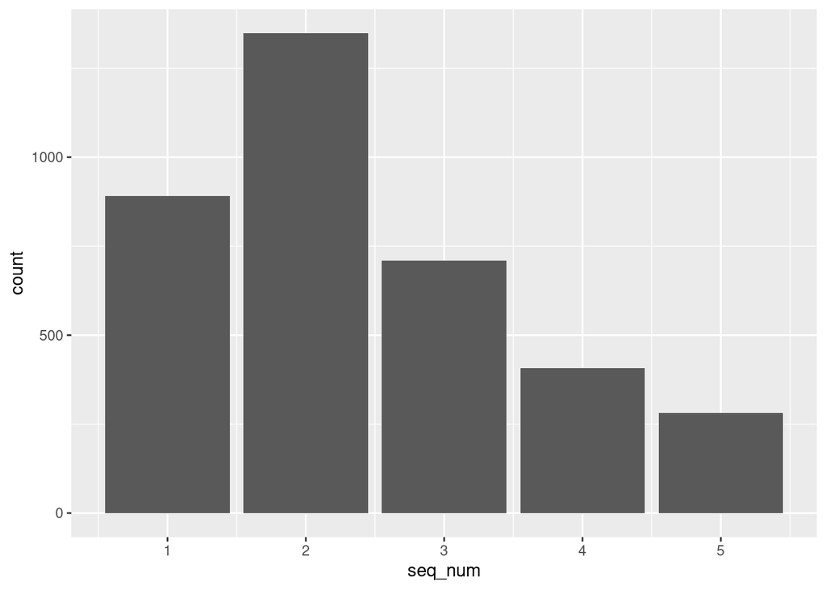

```r
study_admissionsfull %>%
  group_by(seq_num, mortality) %>%
  summarize(count = n()) %>%
  ggplot(aes(x = seq_num, y = count)) +
  geom_col()
```

Let’s try to select the patients that have a 30 day mortality rate that were admitted to the MICU primarily from respiratory illness. There is a total of 890 subjects primarily diagnosed with respiratory illness, we have found that subjects have the icd9_code of 51881 which is acute respiratory failure.

```r
study_admissionsfull %>%
  group_by(subject_id, hadm_id) %>%
  filter(row_number() == 1) %>%
  filter(seq_num == 1) %>%
print() -> studyseq1
```

```
## # Source:   lazy query [?? x 10]
## # Database: postgres 11.0.7 [postgres@/var/run/postgresql:5432/mimic]
## # Groups:   subject_id, hadm_id
##    subject_id hadm_id   age mortality drg_severity icd9_code seq_num
##         <int>   <int> <dbl> <lgl>            <dbl> <chr>       <int>
##  1        191  136614    73 NA                   4 51881           1
##  2        286  106909    85 TRUE                 4 51884           1
##  3        492  114598    40 NA                   4 51881           1
##  4        711  168530    84 TRUE                 4 51881           1
##  5        720  100753    51 NA                   1 51881           1
##  6        720  171046    51 NA                   1 51884           1
##  7        801  170037    47 TRUE                 4 51881           1
##  8        887  166988    56 NA                   1 51881           1
##  9        952  193143    62 TRUE                 1 51881           1
## 10        952  197486    62 TRUE                 1 51881           1
## # … with more rows, and 3 more variables: principal_dx <lgl>, gender <chr>,
## #   ethnic_group <chr>
```

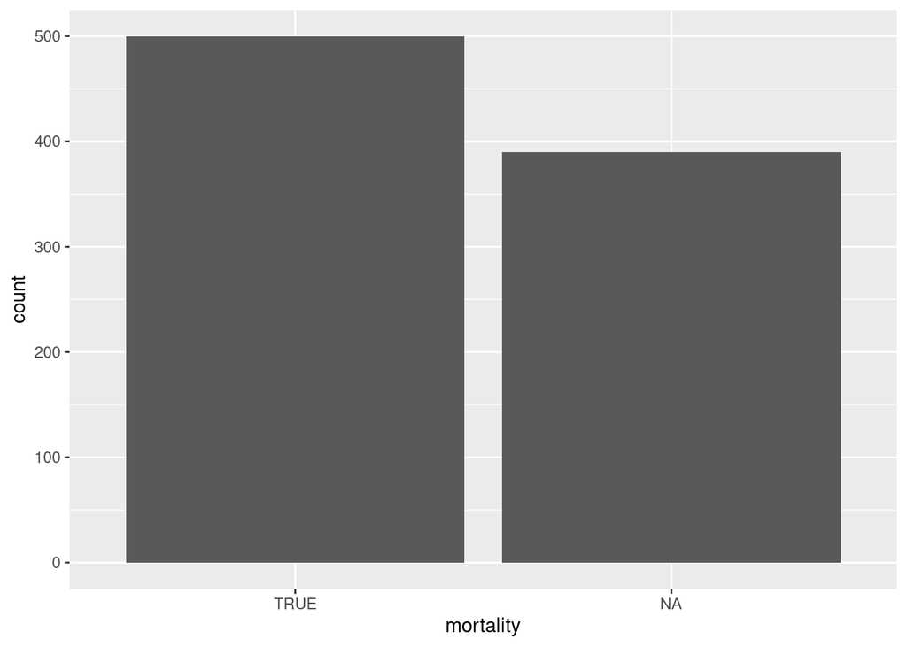

```r
studyseq1 %>%
  group_by(mortality) %>%
  summarize(count = n()) %>%
  ggplot(aes(x = mortality, y = count)) +
  geom_col()
```

Group data by gender.

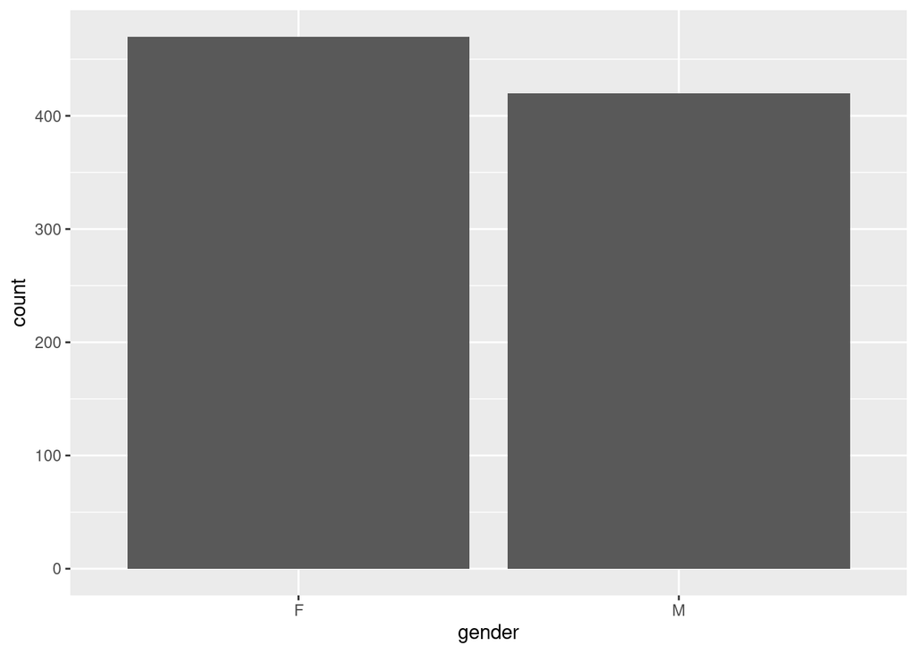

```r
studyseq1 %>%
  group_by(gender) %>%
  summarize(count = n()) %>%
  ggplot(aes(x = gender, y = count)) +
  geom_col()
```

Question 5 - Analytics. Use at least two analytical approaches to address your research hypothesis/goal. **Part 1: Logistic Regression**

```r
head(studyseq1)
```

```
## # Source:   lazy query [?? x 10]
## # Database: postgres 11.0.7 [postgres@/var/run/postgresql:5432/mimic]
## # Groups:   subject_id, hadm_id
##   subject_id hadm_id   age mortality drg_severity icd9_code seq_num principal_dx
##        <int>   <int> <dbl> <lgl>            <dbl> <chr>       <int> <lgl>
## 1        191  136614    73 NA                   4 51881           1 TRUE
## 2        286  106909    85 TRUE                 4 51884           1 TRUE
## 3        492  114598    40 NA                   4 51881           1 TRUE
## 4        711  168530    84 TRUE                 4 51881           1 TRUE
## 5        720  100753    51 NA                   1 51881           1 TRUE
## 6        720  171046    51 NA                   1 51884           1 TRUE
## # … with 2 more variables: gender <chr>, ethnic_group <chr>
```

```r
summary(studyseq1)
```

```
##     Length Class                    Mode
## src 2      src_PostgreSQLConnection list
## ops 4      op_filter                list
```

```r
head(study_admissionsfull)
```

```
## # Source:   lazy query [?? x 10]
## # Database: postgres 11.0.7 [postgres@/var/run/postgresql:5432/mimic]
## # Groups:   subject_id, hadm_id
##   subject_id hadm_id   age mortality drg_severity icd9_code seq_num principal_dx
##        <int>   <int> <dbl> <lgl>            <dbl> <chr>       <int> <lgl>
## 1         36  165660    72 NA                   3 99739           5 FALSE
## 2         94  140037    74 TRUE                 2 51884           2 FALSE
## 3        148  199488    78 TRUE                 1 51881           5 FALSE
## 4        157  107880    80 TRUE                 4 51881           4 FALSE
## 5        165  170252    86 NA                   4 51881           2 FALSE
## 6        170  175350    71 NA                   1 51881           3 FALSE
## # … with 2 more variables: gender <chr>, ethnic_group <chr>
```

```r
study_admissionsfull <- glm(mortality ~ seq_num, data = study_admissionsfull, family = "binomial")
summary(study_admissionsfull)
```

```
##
## Call:
## glm(formula = mortality ~ seq_num, family = "binomial", data = study_admissionsfull)
##
## Deviance Residuals:
##       Min         1Q     Median         3Q        Max
## 2.409e-06  2.409e-06  2.409e-06  2.409e-06  2.409e-06
##
## Coefficients:
##               Estimate Std. Error z value Pr(>|z|)
## (Intercept)  2.657e+01  1.812e+04   0.001    0.999
## seq_num     -1.577e-15  6.738e+03   0.000    1.000
##
## (Dispersion parameter for binomial family taken to be 1)
##
##     Null deviance: 0.0000e+00  on 1807  degrees of freedom
## Residual deviance: 1.0489e-08  on 1806  degrees of freedom
##   (1830 observations deleted due to missingness)
## AIC: 4
##
## Number of Fisher Scoring iterations: 25
```